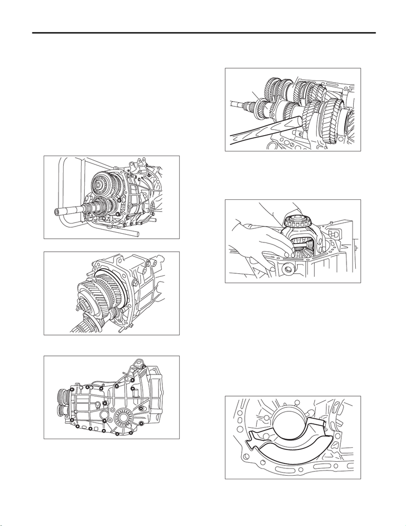

6MT(TY75)-79

Transmission Case

MANUAL TRANSMISSION AND DIFFERENTIAL

15.Transmission Case

A: REMOVAL

1) Remove the manual transmission assembly

from the vehicle. <Ref. to 6MT(TY75)-25, REMOV-

AL, Manual Transmission Assembly.>

2) Remove the clutch release lever and the release

bearing. <Ref. to CL-17, REMOVAL, Release

Bearing and Lever.>

3) Remove the transfer case together with the ex-

tension case assembly. <Ref. to 6MT(TY75)-51,

REMOVAL, Transfer Case and Extension Case

Assembly.>

4) Remove the bearing mounting bolt.

5) Remove the main shaft rear plate.

6) Remove the bolts and nuts, and separate the

transmission case into the right and left cases.

7) Remove the drive pinion shaft assembly.

NOTE:

Use a hammer handle, etc. to remove if too tight.

8) Remove the main shaft assembly.

9) Remove the front differential assembly.

10) Remove the differential side retainers and

taper roller bearing outer races on the left and right

sides. <Ref. to 6MT(TY75)-111, REMOVAL, Front

Differential Assembly.>

NOTE:

Do not confuse the right and left taper roller bearing

outer races.

11) Remove the reverse idler gear. <Ref. to

6MT(TY75)-123, REMOVAL, Reverse Idler Gear.>

12) Remove the shifter fork and rod. <Ref. to

6MT(TY75)-135, REMOVAL, Shifter Fork and

Rod.>

13) Remove the front oil guide.

MT-02466

MT-02467

MT-02468

(A) Main shaft ASSY

(B) Drive pinion shaft ASSY

MT-01877

(A)

(B)

MT-02469

MT-02537

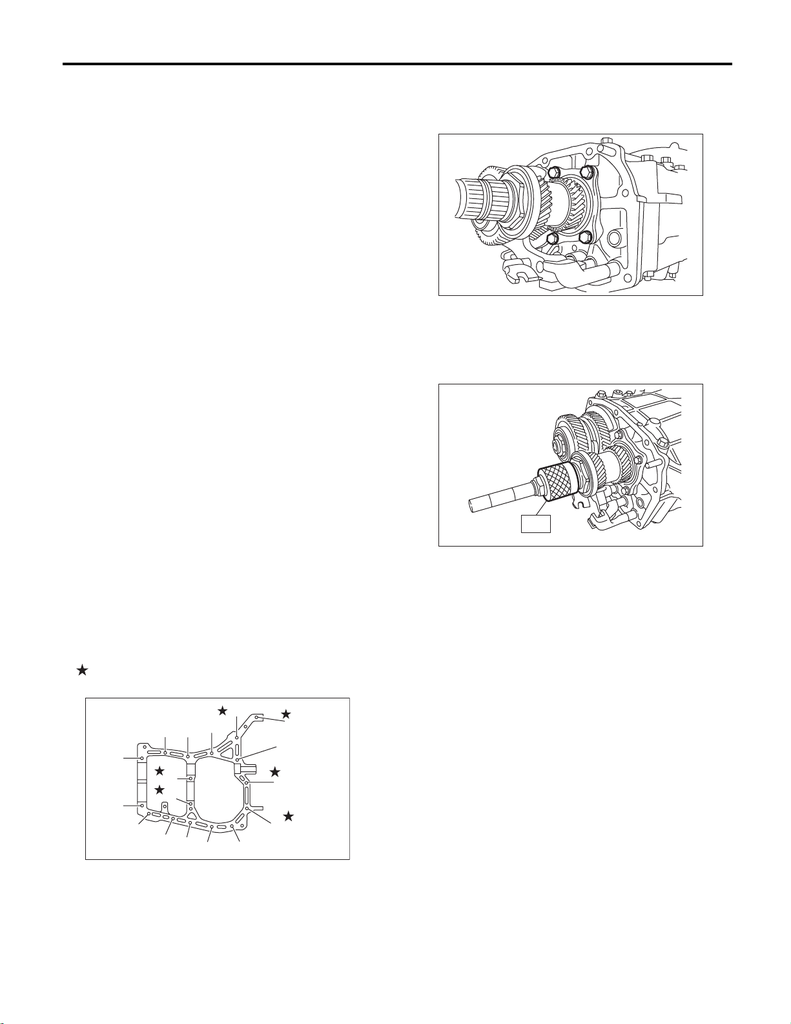

6MT(TY75)-80

Transmission Case

MANUAL TRANSMISSION AND DIFFERENTIAL

B: INSTALLATION

1) Wipe off grease, oil and dust on the mating sur-

faces of transmission cases with cleaning solvent.

2) Install the shifter fork and rod. <Ref. to

6MT(TY75)-137, INSTALLATION, Shifter Fork and

Rod.>

3) Install the reverse idler gear. <Ref. to

6MT(TY75)-125, INSTALLATION, Reverse Idler

Gear.>

4) Select the drive pinion shim. <Ref. to

6MT(TY75)-92, INSTALLATION, Drive Pinion

Shaft Assembly.>

5) Install the taper roller bearing outer race to the

transmission case LH side, and install the differen-

tial side retainer with the O-ring removed.

6) Install the front differential assembly.

7) Install the main shaft assembly.

NOTE:

Align to install the needle bearing knock pin hole to

the transmission case knock pin.

8) Install the selected drive pinion shims and drive

pinion shaft assembly.

NOTE:

Align the roller bearing knock pin hole to the trans-

mission case knock pin.

9) Align the left and right side of the transmission

case, and tighten it with 17 mounting bolts.

NOTE:

• Insert bolts (11) and (16) from the LH side of the

transmission case.

• Match the cases together so that the drive pinion

shims are not caught between the cases.

Tightening torque:

8 mm bolt

25 N·m (2.5 kgf-m, 18.4 ft-lb)

10 mm bolt

40 N·m (4.1 kgf-m, 29.5 ft-lb)

10) Install the taper roller bearing outer race to the

RH side of the transmission case.

11) Tighten the bearing mounting bolts.

Tightening torque:

30 N·m (3.1 kgf-m, 22.1 ft-lb)

12) Perform backlash adjustment of the hypoid

driven gear and preload adjustment of the taper

roller bearing.

(1) Attach the ST on drive pinion assembly.

ST 18667AA020 HOLDER

(2) Place the transmission case with the LH

side facing downward, and put ST1 on the taper

roller bearing outer race.

MT-00172

(9)

(7)

(5)

(1)

(2)

(16)

(17)

(11)

(3)

(4)

(12)

(8)

(6)

(10)

(14)

(15)

(13)

MT-02470

ST

MT-02471

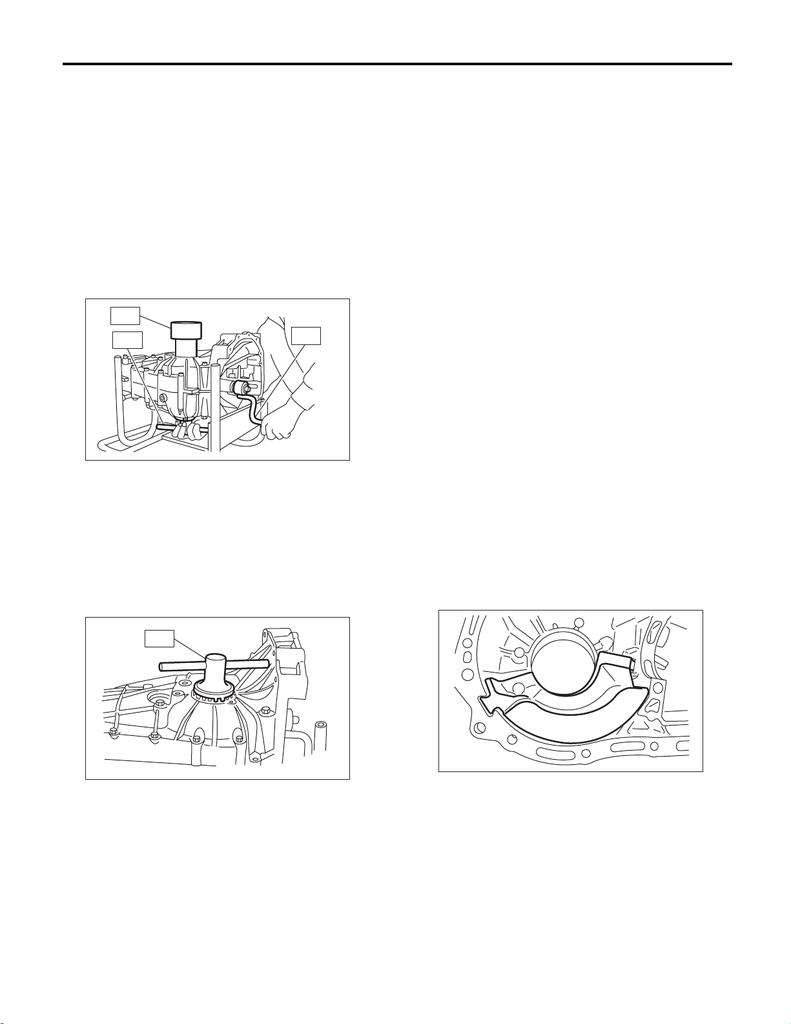

6MT(TY75)-81

Transmission Case

MANUAL TRANSMISSION AND DIFFERENTIAL

(3) Screw the differential side retainer from the

bottom into LH side case using ST2. Fit the ST3

on the main shaft. Shift the gear into 4th or 5th,

and turn the shaft several times. Screw in the

differential side retainer while rotating the ST3

until a slight resistance is felt on ST2.

This is the contact point of the hypoid driven

gear and the drive pinion shaft. Repeat the

above sequence several times to ensure the

contact point.

ST1 399780104 WEIGHT

ST2 18630AA010 WRENCH COMPL RETAIN-

ER

ST3 499927100 HANDLE

(4) Remove the WEIGHT, and screw in the dif-

ferential side retainer without the O-ring into the

RH side of the transmission case, and stop at

the point where a slight resistance is felt.

NOTE:

In this condition, the backlash between hypoid driv-

en gear and drive pinion shaft is zero.

ST 18630AA010 WRENCH COMPL RETAIN-

ER

(5) Loosen the differential side retainer on the

LH side of the transmission case by 3 notches,

and turn the differential side retainer on the RH

side of the transmission case by 3 notches in

order to apply backlash.

(6) Screw in the differential side retainer of the

RH side of the transmission case additionally by

1 notch in order to apply preload on taper roller

bearing.

(7) Tighten temporarily both the retainer lock

plates LH and RH, and put marks on both the

differential side retainer and retainer lock plate

for later readjustment.

NOTE:

When it is difficult to attach the retainer lock plate,

turn over the retainer lock plate and attach.

(8) Turn the transmission main shaft several

times while tapping around the differential side

retainer lightly with plastic hammer.

13) Inspect and adjust backlash and tooth contact

of the hypoid driven gear. <Ref. to 6MT(TY75)-117,

INSPECTION, Front Differential Assembly.>

14) Separate the transmission case into left and

right parts. <Ref. to 6MT(TY75)-79, REMOVAL,

Transmission Case.>

15) Check each shifter fork. <Ref. to 6MT(TY75)-

140, INSPECTION, Shifter Fork and Rod.>

16) Select a main shaft rear plate. <Ref. to

6MT(TY75)-91, ADJUSTMENT, Main Shaft As-

sembly for Single-Range.>

17) Install the front oil guide.

NOTE:

Fit in all the way.

MT-02666

ST3

ST2

ST1

MT-02667

ST

MT-02537

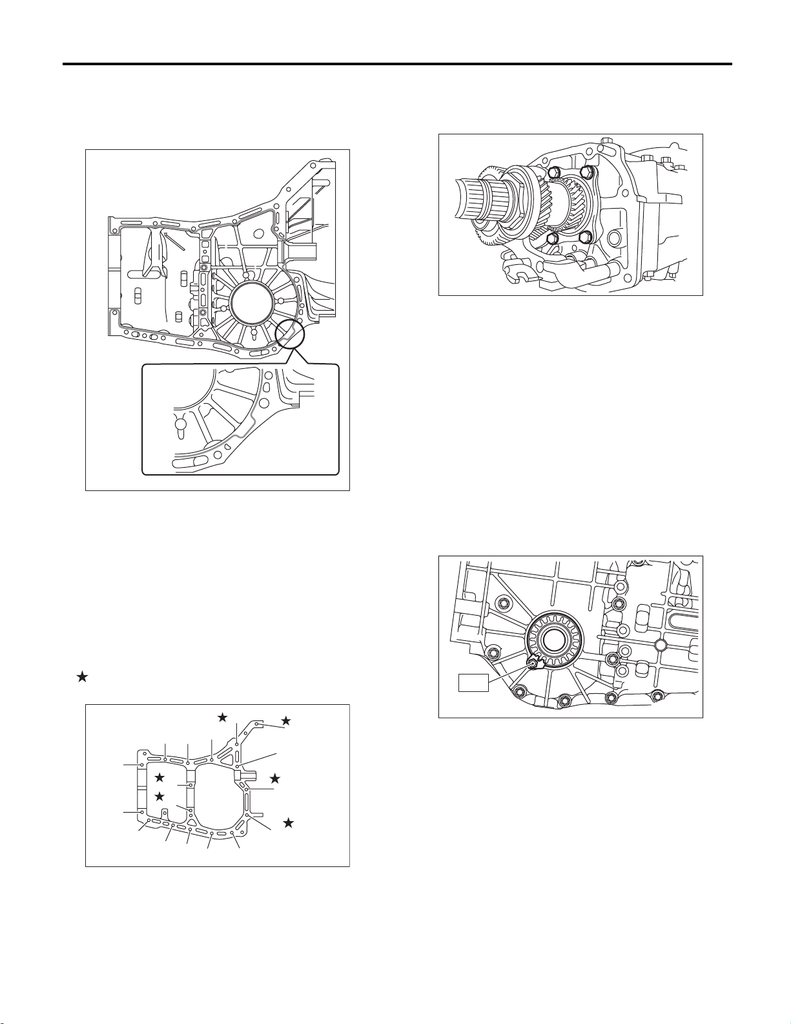

6MT(TY75)-82

Transmission Case

MANUAL TRANSMISSION AND DIFFERENTIAL

18) Apply liquid gasket, then join the right side and

left side of the case together.

Liquid gasket:

THREE BOND 1215B or equivalent

19) Tighten 17 bolts with brackets and clips as

shown in the figure.

NOTE:

• Insert bolts (11) and (16) from the LH side of the

transmission case.

• Match the cases together so that the drive pinion

shims are not caught between the cases.

Tightening torque:

8 mm bolt

25 N·m (2.5 kgf-m, 18.4 ft-lb)

10 mm bolt

40 N·m (4.1 kgf-m, 29.5 ft-lb)

20) Tighten the bearing mounting bolts.

Tightening torque:

30 N·m (3.1 kgf-m, 22.1 ft-lb)

21) Remove the retainer lock plate, and loosen the

differential side retainer until the groove of the O-

ring appears. Fit the O-ring into the groove and

tighten the differential side retainer into the position

where it was not loosened.

NOTE:

• When loosening the differential side retainer,

record the number of the turns made.

• Perform this for both left and right differential

side retainers.

• Use new O-rings.

• Apply gear oil to O-ring.

22) Install the retainer lock plate.

Tightening torque:

T: 25 N·m (2.5 kgf-m, 18.4 ft-lb)

23) Install the transfer case together with the exten-

sion case assembly. <Ref. to 6MT(TY75)-53, IN-

STALLATION, Transfer Case and Extension Case

Assembly.>

24) Install the clutch release lever and release

bearing. <Ref. to CL-17, INSTALLATION, Release

Bearing and Lever.>

25) Install the manual transmission assembly to the

vehicle. <Ref. to 6MT(TY75)-30, INSTALLATION,

Manual Transmission Assembly.>

C: INSPECTION

Check the transmission case for cracks, damage,

or oil leaks.

MT-02433

MT-00172

(9)

(7)

(5)

(1)

(2)

(16)

(17)

(11)

(3)

(4)

(12)

(8)

(6)

(10)

(14)

(15)

(13)

MT-02470

MT-02665

T